# Pertemuan 7

Nadila Putri Fauziyyah - G1401211028

2023-10-11

## Packages

```r
library(ggplot2)
library(tsibble)
library(tseries)
library(MASS)
library(forecast)
library(TSA)
library(TTR)
library(aTSA)
library(graphics)
```

## Input Data

```r
data1 <- rio::import("https://raw.githubusercontent.com/nadilaputrif/MPDW-NadilaPF/main/Data/Data_suhu.csv")
data1
```

```
##     Periode  Suhu
## 1         1 23.71
## 2         2 24.76
## 3         3 24.73
## 4         4 24.76
## 5         5 25.03
## 6         6 24.08
## 7         7 23.79
## 8         8 23.91
## 9         9 23.91
## 10       10 23.58
## 11       11 24.02
## 12       12 23.20
## 13       13 24.12
## 14       14 22.95
```

[output cut: 142 more lines]

### Eksplorasi Data

#### Plot Data Penuh

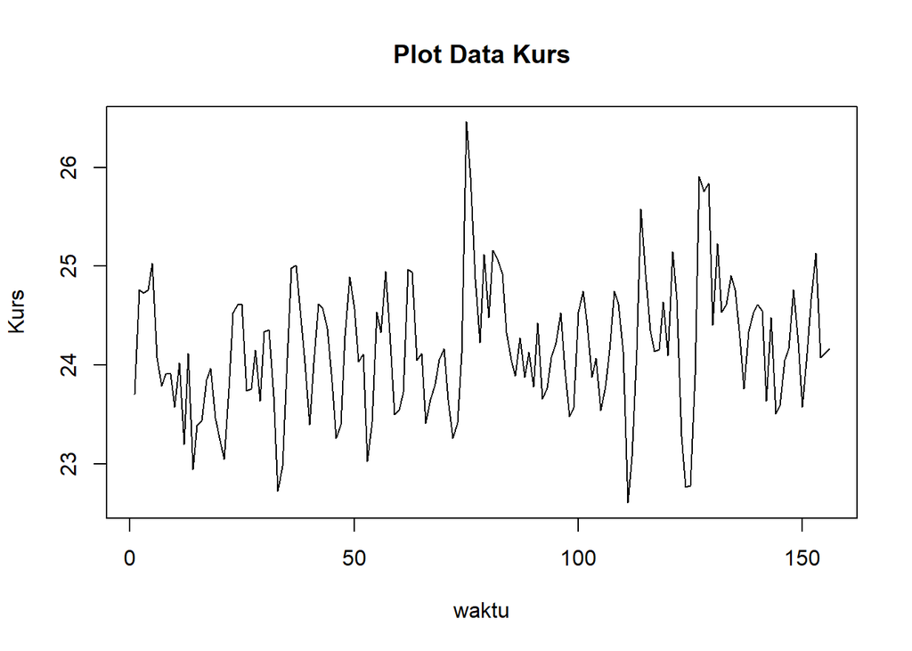

```r
data1.ts <-ts(data1$Suhu)
plot.ts(data1.ts, lty=1, xlab="waktu", ylab="Kurs", main="Plot Data Kurs")
```

Berdasarkan plot data deret waktu, terlihat bahwa data cenderung stasioner. Berdasarkan pola data, pembagian data latih dan data uji ditetapkan dengan proporsi 80%:20%

#### Plot Data Latih

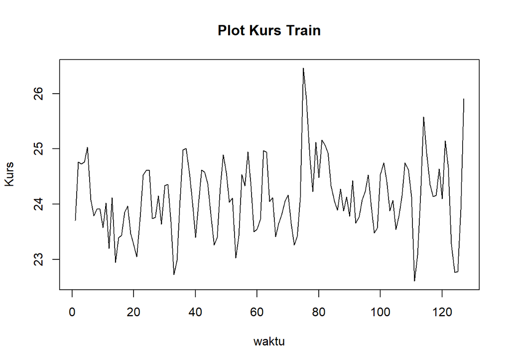

```r
train<-data1.ts[1:127]
train.ts<-ts(train)
plot.ts(train.ts, lty=1, xlab="waktu", ylab="Kurs", main="Plot Kurs Train")
```

Berdasarkan plot data deret waktu pada data latih, terlihat bahwa data stasioner.

#### Plot Data Uji

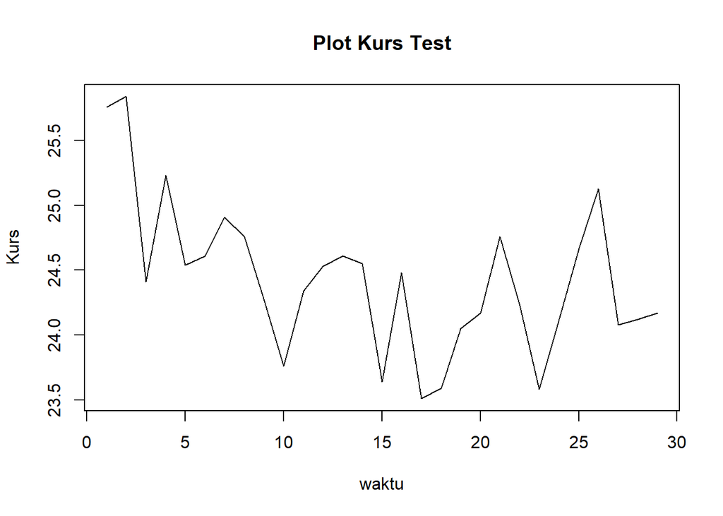

```r
test<-data1.ts[128:156]
test.ts<-ts(test)
plot.ts(test.ts, lty=1, xlab="waktu", ylab="Kurs", main="Plot Kurs Test")
```

### Uji Stasioneritas Data

#### Plot ACF

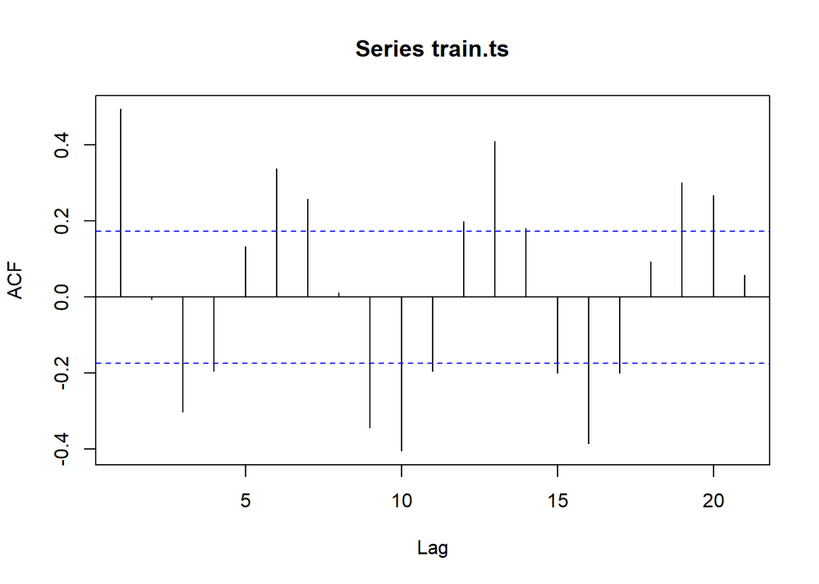

```r
acf(train.ts)
```

Berdasarkan plot ACF, terlihat bahwa plot ACF data *tails of* dan membentuk pola sinus.

#### Uji ADF

```r
tseries::adf.test(train.ts)
```

```
##
##  Augmented Dickey-Fuller Test
##
## data:  train.ts
## Dickey-Fuller = -3.6336, Lag order = 5, p-value = 0.03309
## alternative hypothesis: stationary
```

$H_0$ : Data tidak stasioner dalam rataan

$H_1$ : Data stasioner dalam rataan

#### Plot Box-Cox

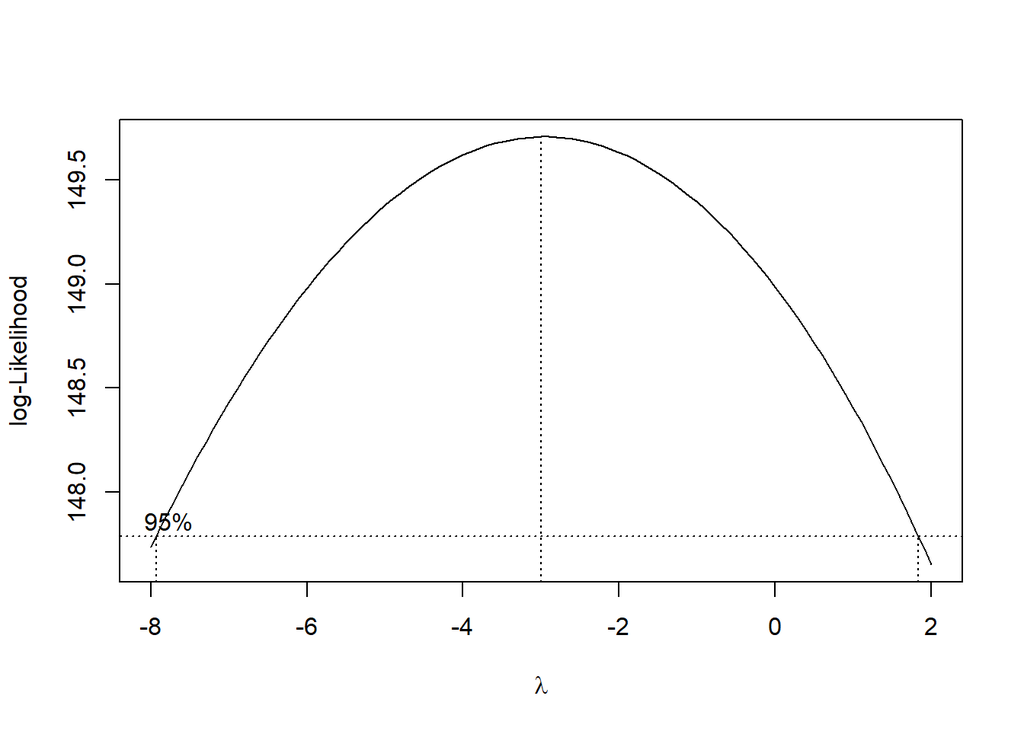

```r
index <- seq(1:127)
bc = boxcox(train.ts~index, lambda = seq(-8,2,by=0.1))
```

```r
#Nilai Rounded Lambda
lambda <- bc$x[which.max(bc$y)]
lambda
```

```
## [1] -3
```

```r
#SK
bc$x[bc$y > max(bc$y) - 1/2 * qchisq(.95,1)]
```

```
##  [1] -7.9 -7.8 -7.7 -7.6 -7.5 -7.4 -7.3 -7.2 -7.1 -7.0 -6.9 -6.8 -6.7 -6.6 -6.5
## [16] -6.4 -6.3 -6.2 -6.1 -6.0 -5.9 -5.8 -5.7 -5.6 -5.5 -5.4 -5.3 -5.2 -5.1 -5.0
## [31] -4.9 -4.8 -4.7 -4.6 -4.5 -4.4 -4.3 -4.2 -4.1 -4.0 -3.9 -3.8 -3.7 -3.6 -3.5
## [46] -3.4 -3.3 -3.2 -3.1 -3.0 -2.9 -2.8 -2.7 -2.6 -2.5 -2.4 -2.3 -2.2 -2.1 -2.0
## [61] -1.9 -1.8 -1.7 -1.6 -1.5 -1.4 -1.3 -1.2 -1.1 -1.0 -0.9 -0.8 -0.7 -0.6 -0.5
## [76] -0.4 -0.3 -0.2 -0.1  0.0  0.1  0.2  0.3  0.4  0.5  0.6  0.7  0.8  0.9  1.0
## [91]  1.1  1.2  1.3  1.4  1.5  1.6  1.7  1.8
```

Plot Boxcox menunjukkan nilai *rounded value* ($\lambda$) optimum sebesar **-3** dan pada selang kepercayaan 95% nilai memiliki batas bawah **-7.9** dan batas atas **1.8**. Selang tersebut memuat nilai satu sehingga dapat dikatakan bahwa data stasioner dalam ragam.

### Identifikasi Model

#### Plot ACF

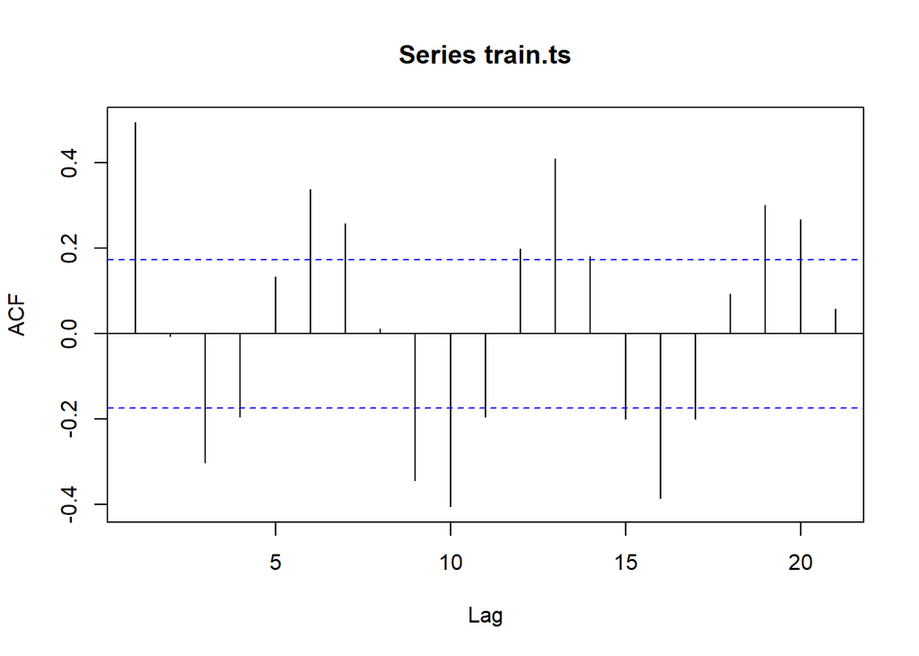

```r
acf(train.ts)
```

#### Plot PACF

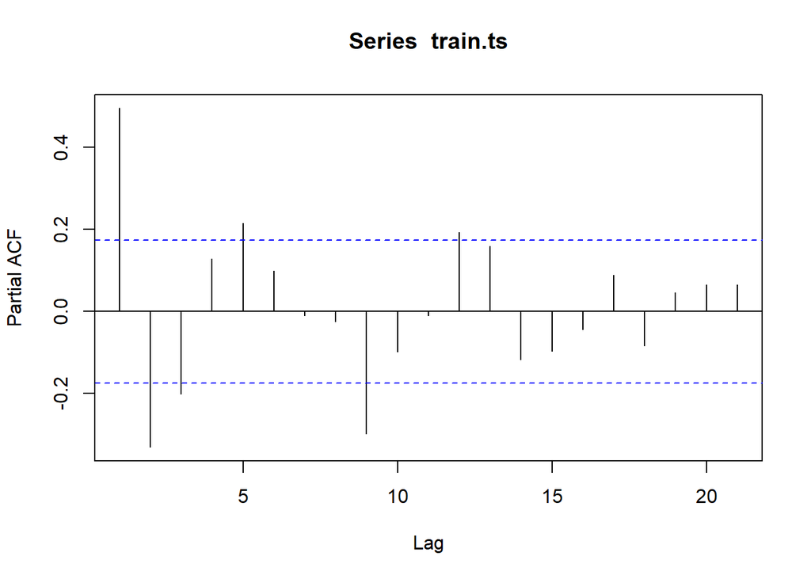

```r
pacf(train.ts)
```

Berdasarkan plot tersebut, terlihat bahwa plot PACF cenderung *cuts off* pada lag ke 3, sehingga jika plot ACF dianggap *tails of*, maka model tentatifnya adalah ARIMA(3,0,0).

Jika baik plot ACF maupun plot PACF keduanya dianggap tails of, maka model yang terbentuk adalah ARIMA(3,0,1)

#### Plot EACF

```r
eacf(train.ts)
```

```
## AR/MA
##   0 1 2 3 4 5 6 7 8 9 10 11 12 13
## 0 x o x x o x x o x x x  x  x  o
## 1 x o x o o x x o x x x  o  x  o
## 2 x x o o o o o o o o o  o  o  o
## 3 x x o o o o o o o o o  o  o  o
## 4 x x o o o o o o o o o  o  o  o
## 5 x x o o o o o o o o o  o  o  o
## 6 o x o o x o o o o o o  o  o  o
## 7 o o o x x o o o o o o  o  o  o
```

Identifikasi model menggunakan plot EACF dilakukan dengan melihat ujung segitiga pada pola segitiga nol. Dalam hal ini model tentatif yang terbentuk adalah ARIMA(2,0,2), ARIMA(3,0,2).

### Pendugaan Parameter Model Tentatif

#### ARIMA(0,0,1)

```r
model1.da=Arima(train.ts, order=c(0,0,1),method="ML")
summary(model1.da) #AIC=222.94
```

```
## Series: train.ts
## ARIMA(0,0,1) with non-zero mean
##
## Coefficients:
##          ma1     mean
##       0.5301  24.1152
## s.e.  0.0608   0.0769
##
## sigma^2 = 0.3274:  log likelihood = -108.47
## AIC=222.94   AICc=223.13   BIC=231.47
##
## Training set error measures:
##                       ME      RMSE       MAE         MPE    MAPE      MASE
## Training set 0.001698489 0.5677023 0.4236298 -0.05152304 1.75432 0.8252528
##                   ACF1
## Training set 0.1229377
```

```r
lmtest::coeftest(model1.da) #seluruh parameter signifikan
```

```
##
## z test of coefficients:
##
##            Estimate Std. Error  z value  Pr(>|z|)
## ma1        0.530144   0.060835   8.7144 < 2.2e-16 ***
## intercept 24.115179   0.076873 313.7004 < 2.2e-16 ***
## ---
## Signif. codes:  0 '***' 0.001 '**' 0.01 '*' 0.05 '.' 0.1 ' ' 1
```

#### ARIMA(3,0,0)

```r
model2.da=Arima(train.ts, order=c(3,0,0),method="ML")
summary(model2.da) #AIC=204.5
```

```
## Series: train.ts
## ARIMA(3,0,0) with non-zero mean
##
## Coefficients:
##          ar1      ar2      ar3     mean
##       0.6607  -0.2396  -0.2267  24.1130
## s.e.  0.0893   0.1061   0.0907   0.0574
##
## sigma^2 = 0.2777:  log likelihood = -97.25
## AIC=204.5   AICc=204.99   BIC=218.72
##
## Training set error measures:
##                       ME      RMSE       MAE         MPE     MAPE      MASE
## Training set 0.002716124 0.5186069 0.3842293 -0.03469163 1.592191 0.7484986
##                    ACF1
## Training set 0.03056345
```

```r
lmtest::coeftest(model2.da) #seluruh parameter signifikan
```

```
##
## z test of coefficients:
##
##            Estimate Std. Error  z value  Pr(>|z|)
## ar1        0.660737   0.089294   7.3996 1.366e-13 ***
## ar2       -0.239550   0.106080  -2.2582   0.02393 *
## ar3       -0.226690   0.090678  -2.5000   0.01242 *
## intercept 24.112967   0.057433 419.8432 < 2.2e-16 ***
## ---
## Signif. codes:  0 '***' 0.001 '**' 0.01 '*' 0.05 '.' 0.1 ' ' 1
```

#### ARIMA(3,0,2)

```r
model3.da=Arima(train.ts, order=c(3,0,2),method="ML")
summary(model3.da) #AIC=178.17
```

```
## Series: train.ts
## ARIMA(3,0,2) with non-zero mean
##
## Coefficients:
##          ar1      ar2     ar3      ma1     ma2     mean
##       1.6489  -1.5839  0.5158  -1.1606  0.9998  24.1227
## s.e.  0.0796   0.0900  0.0795   0.0335  0.0495   0.0790
##
## sigma^2 = 0.2105:  log likelihood = -82.08
## AIC=178.17   AICc=179.11   BIC=198.08
##
## Training set error measures:
##                        ME      RMSE       MAE         MPE     MAPE      MASE
## Training set -0.001836248 0.4478191 0.3313305 -0.04605205 1.370938 0.6454491
##                      ACF1
## Training set -0.005190704
```

```r
lmtest::coeftest(model3.da) #seluruh parameter signifikan
```

```
##
## z test of coefficients:
##
##            Estimate Std. Error  z value  Pr(>|z|)
## ar1        1.648900   0.079629  20.7074 < 2.2e-16 ***
## ar2       -1.583893   0.089953 -17.6080 < 2.2e-16 ***
## ar3        0.515821   0.079510   6.4875 8.727e-11 ***
## ma1       -1.160643   0.033504 -34.6417 < 2.2e-16 ***
## ma2        0.999795   0.049546  20.1792 < 2.2e-16 ***
## intercept 24.122700   0.078984 305.4123 < 2.2e-16 ***
## ---
## Signif. codes:  0 '***' 0.001 '**' 0.01 '*' 0.05 '.' 0.1 ' ' 1
```

#### ARIMA(3,0,1)

```r
model4.da=Arima(train.ts, order=c(3,0,1),method="ML")
summary(model4.da) #AIC=205.33
```

```
## Series: train.ts
## ARIMA(3,0,1) with non-zero mean
##
## Coefficients:
##          ar1      ar2      ar3     ma1     mean
##       0.4044  -0.0445  -0.3400  0.2674  24.1132
## s.e.  0.2474   0.1890   0.1185  0.2525   0.0595
##
## sigma^2 = 0.2773:  log likelihood = -96.66
## AIC=205.33   AICc=206.03   BIC=222.39
##
## Training set error measures:
##                       ME      RMSE       MAE         MPE     MAPE      MASE
## Training set 0.002649453 0.5161603 0.3852929 -0.03452875 1.596593 0.7505705
##                    ACF1
## Training set 0.01116433
```

```r
lmtest::coeftest(model4.da) #ar3 dan intersep yang signifikan
```

```
##
## z test of coefficients:
##
##            Estimate Std. Error  z value Pr(>|z|)
## ar1        0.404374   0.247406   1.6345   0.1022
## ar2       -0.044458   0.189014  -0.2352   0.8140
## ar3       -0.340036   0.118464  -2.8704   0.0041 **
## ma1        0.267437   0.252490   1.0592   0.2895
## intercept 24.113151   0.059490 405.3324   <2e-16 ***
## ---
## Signif. codes:  0 '***' 0.001 '**' 0.01 '*' 0.05 '.' 0.1 ' ' 1
```

Berdasarkan pendugaan parameter di atas, nilai AIC terkecil dimiliki oleh model ARIMA(3,0,2)dengan seluruhnya signifikan sehingga model yang dipilih adalah model ARIMA(3,0,2).

### Analisis Sisaan

#### Eksplorasi Sisaan

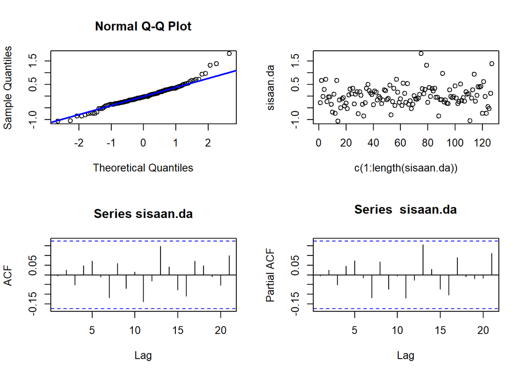

```r
#Eksplorasi
sisaan.da <- model3.da$residuals
par(mfrow=c(2,2))
qqnorm(sisaan.da)
qqline(sisaan.da, col = "blue", lwd = 2)
plot(c(1:length(sisaan.da)),sisaan.da)
acf(sisaan.da)
pacf(sisaan.da)
```

```r
par(mfrow = c(1,1))
```